# Permutation Analysis on Factors Obtain from MCF10A Treated Expression Data

– P value ~ KO Associations

Yifan Zhou (zhouyf@uchicago.edu)

2020-11-10

For each factor analysis result, we did 1000 permutaions on the cell labels, and correlated the permuted KO conditions with the factors.

The empirical p value distribution is plotted by combining the association p values between the 20 factors and the 30 knock-out (KO) conditions over 1000 permutations ($20\times 30\times 1000 = 6\times 10^5$ p values in total).

# 1 Genes Filtered by Detection Rate

## 1.1 GSFA Detection > 10% (8046 genes)

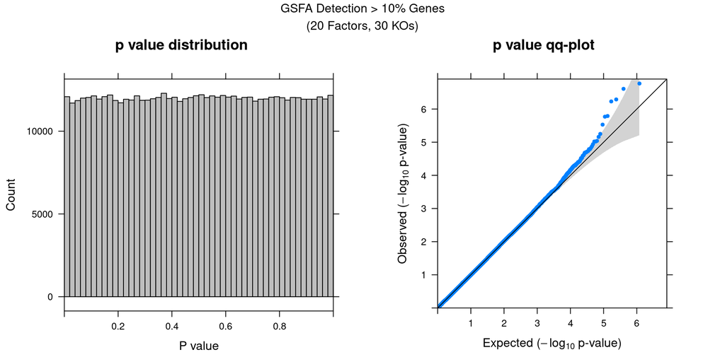

P value distribution by each factor:

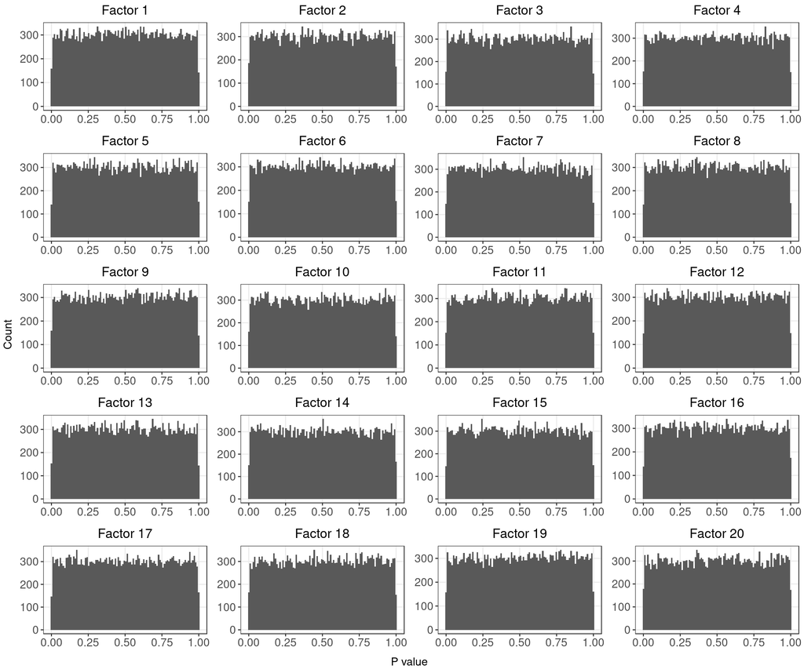

## 1.2 FLASH Detection > 10%

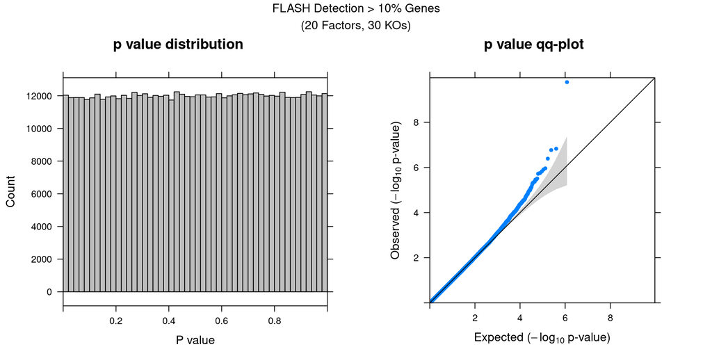

## 1.3 GSFA Detection > 5% (9895 genes)

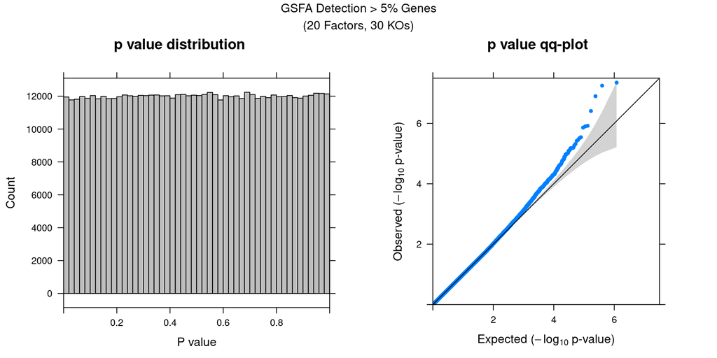

## 1.4 FLASH Detection > 5%

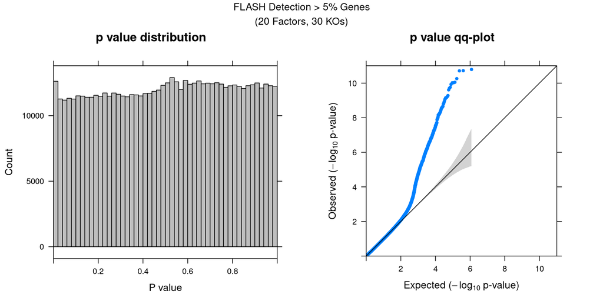

# 2 Genes Filtered by Variance

**As shown below, permutated p value distribution deviates greatly from uniform for some later factors.**

## 2.1 GSFA on Top 8K Variable Genes

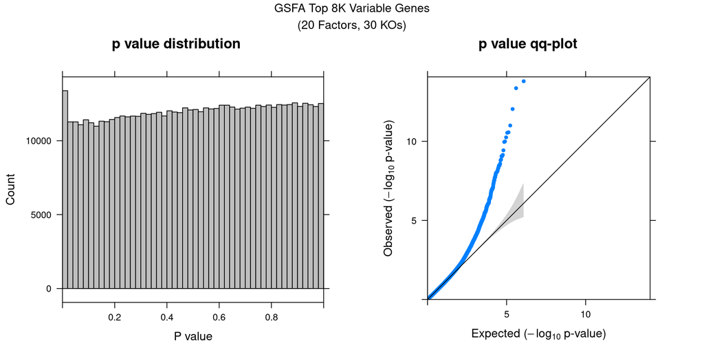

P value distribution by each factor:

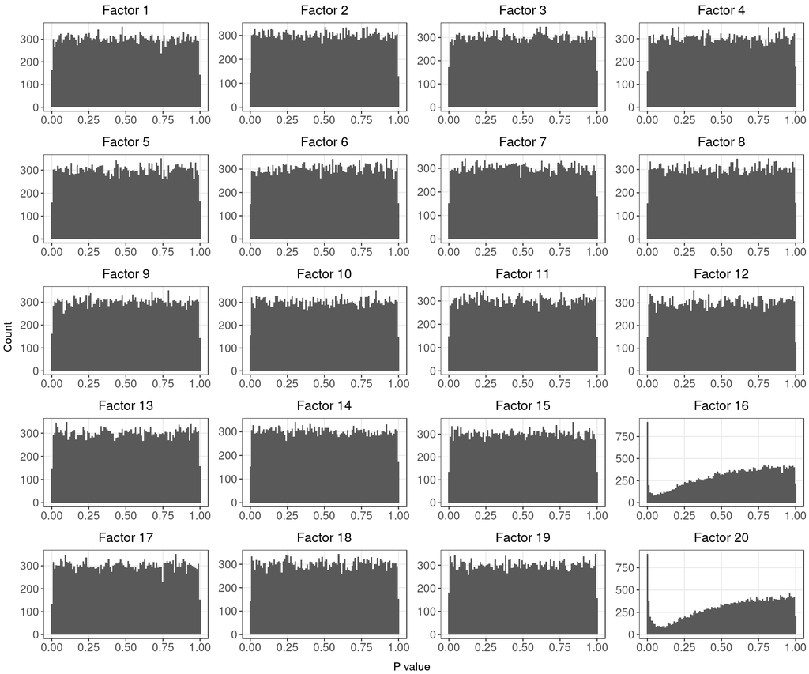

## 2.2 FLASH on Top 8K Variable Genes

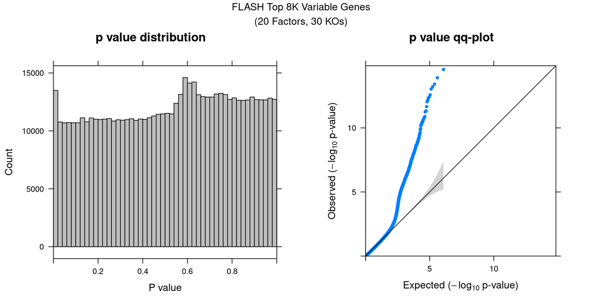

P value distribution by each factor:

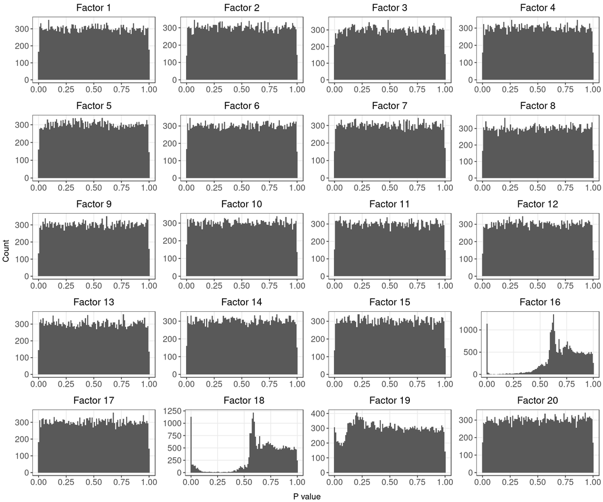

## 2.3 GSFA on Top 10K Variable Genes

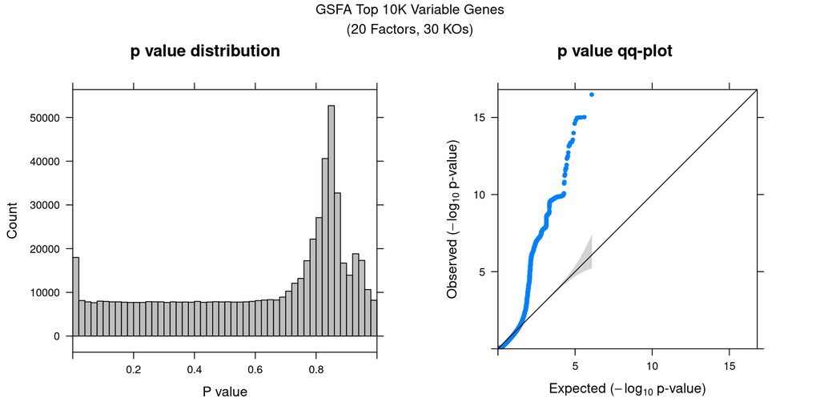

P value distribution by each factor:

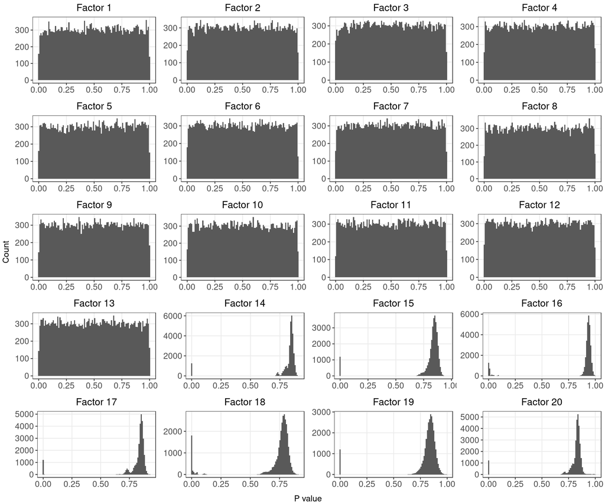

## 2.4 FLASH on Top 10K Variable Genes

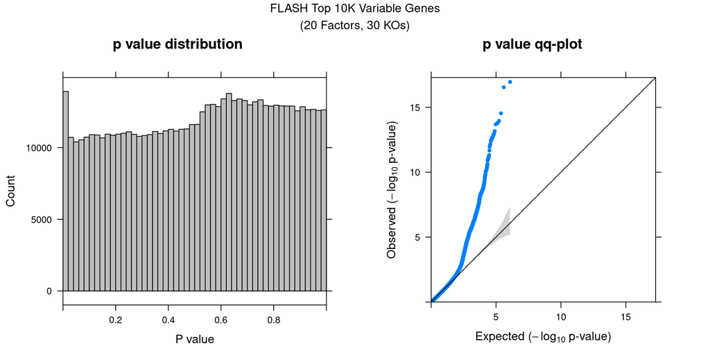

P value distribution by each factor:

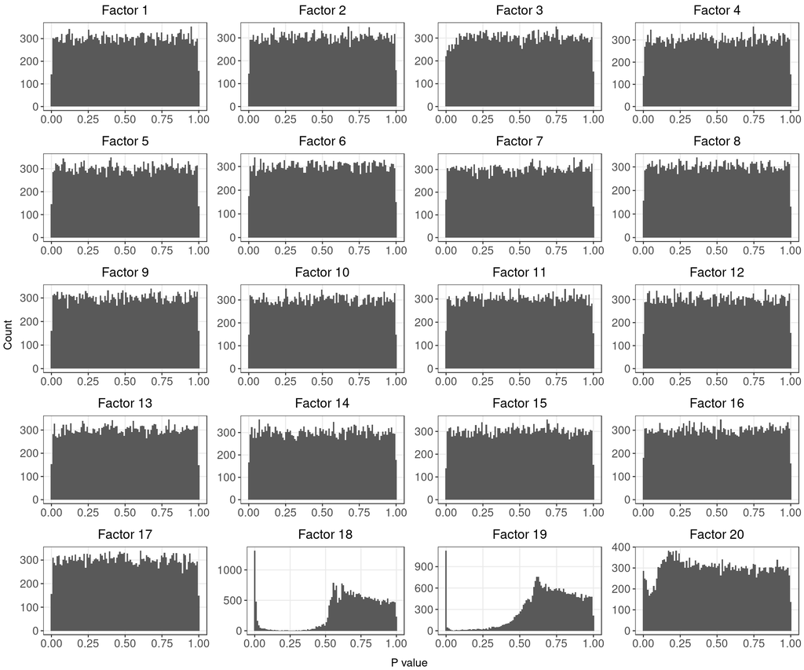